# R Programming Midterm 201701 - 01

coop711

2017-05-03

#### Excel 자료 읽어들이기

- excel 파일을 잘 읽어들이는 `xlsx` 패키지를 올려놓고, 자료구조에 맞춰 argument 설정.
  - Sheet 번호, startRow, colIndex, header 의 용도 파악.

```r
midterm.roll <- read.xlsx("../data/midterm_01.xlsx",
                          sheetIndex = 1,
                          startRow = 3,
                          endRow  = 32,
                          colIndex = c(4, 10:49),
                          colClasses = rep("character", 41),
                          encoding = "UTF-8",
                          header = FALSE,
                          stringsAsFactors = FALSE)
names(midterm.roll) <- c("id", paste("Q", 1:40, sep = ""))
kable(head(midterm.roll[, 2:21]))
```

| Q1 | Q2 | Q3 | Q4 | Q5 | Q6 | Q7 | Q8 | Q9 | Q10 | Q11 | Q12 | Q13 | Q14 | Q15 | Q16 | Q17 | Q18 | Q19 | Q20 |
| --- | --- | --- | --- | --- | --- | --- | --- | --- | --- | --- | --- | --- | --- | --- | --- | --- | --- | --- | --- |
| 4 | 4 | 4 | 4 | 1 | 4 | 2 | 4 | 1 | 2 | 2 | 4 | 1 | 2 | 1 | 2 | 1 | 2 | 3 | 2 |
| 4 | 4 | 3 | 1 | 1 | 4 | 2 | 4 | 1 | 1 | 2 | 2 | 1 | 1 | 2 | 3 | 3 | 2 | 1 | 2 |
| 4 | 4 | 4 | 1 | 1 | 4 | 2 | 4 | 1 | 2 | 4 | 4 | 1 | 1 | 2 | 3 | 3 | 2 | 1 | 1 |
| 4 | 4 | 4 | 1 | 1 | 4 | 2 | 4 | 1 | 2 | 2 | 4 | 1 | 2 | 2 | 1 | 3 | 2 | 2 | 2 |
| 4 | 4 | 3 | 1 | 1 | 4 | 2 | 4 | 2 | 2 | 2 | 4 | 1 | 1 | 2 | 3 | 2 | 2 | 1 | 2 |
| 4 | 4 | 4 | 1 | 1 | 4 | 2 | 4 | 1 | 2 | 2 | 3 | 1 | 1 | 2 | 3 | 4 | 2 | 3 | 2 |

```r
kable(head(midterm.roll[, 22:41]))
```

| Q21 | Q22 | Q23 | Q24 | Q25 | Q26 | Q27 | Q28 | Q29 | Q30 | Q31 | Q32 | Q33 | Q34 | Q35 | Q36 | Q37 | Q38 | Q39 | Q40 |
| --- | --- | --- | --- | --- | --- | --- | --- | --- | --- | --- | --- | --- | --- | --- | --- | --- | --- | --- | --- |
| 1 | 3 | 1 | 1 | 2 | 3 | 4 | 2 | 1 | 2 | 1 | 4 | 1 | 2 | 2 | 4 | 2 | 1 | 3 | 2 |
| 1 | 3 | 4 | 3 | 4 | 3 | 4 | NA | 2 | 4 | 1 | 4 | 3 | 2 | 2 | 2 | 3 | 1 | 3 | 4 |
| 1 | 3 | 4 | 3 | 1 | 3 | 2 | 2 | 1 | 1 | 4 | 4 | 4 | 2 | 2 | 4 | 2 | 3 | 2 | 3 |
| 1 | 3 | 2 | 2 | 1 | 1 | 1 | 2 | 1 | 1 | 1 | 4 | 1 | 2 | 2 | 4 | 4 | 4 | 3 | 3 |
| 1 | 4 | 1 | 2 | 1 | 3 | 2 | 4 | 2 | 1 | 1 | 4 | 1 | 2 | 2 | 2 | 1 | 2 | 3 | 2 |
| 1 | 4 | 4 | 3 | 1 | 3 | 2 | 2 | 1 | 1 | 3 | 4 | 1 | 2 | 2 | 2 | 3 | 3 | 3 | 4 |

```r
str(midterm.roll)
```

```
## 'data.frame':    30 obs. of  41 variables:
##  $ id : chr  "20143402" "20122807" "20163201" "20163202" ...
##  $ Q1 : chr  "4" "4" "4" "4" ...
##  $ Q2 : chr  "4" "4" "4" "4" ...
##  $ Q3 : chr  "4" "3" "4" "4" ...
##  $ Q4 : chr  "4" "1" "1" "1" ...
##  $ Q5 : chr  "1" "1" "1" "1" ...
##  $ Q6 : chr  "4" "4" "4" "4" ...
##  $ Q7 : chr  "2" "2" "2" "2" ...
##  $ Q8 : chr  "4" "4" "4" "4" ...
##  $ Q9 : chr  "1" "1" "1" "1" ...
##  $ Q10: chr  "2" "1" "2" "2" ...
##  $ Q11: chr  "2" "2" "4" "2" ...
##  $ Q12: chr  "4" "2" "4" "4" ...
##  $ Q13: chr  "1" "1" "1" "1" ...
```

[output cut: 27 more lines]

```r
midterm <- midterm.roll[, -1]
kable(midterm[1:16])
```

| Q1 | Q2 | Q3 | Q4 | Q5 | Q6 | Q7 | Q8 | Q9 | Q10 | Q11 | Q12 | Q13 | Q14 | Q15 | Q16 |
| --- | --- | --- | --- | --- | --- | --- | --- | --- | --- | --- | --- | --- | --- | --- | --- |
| 4 | 4 | 4 | 4 | 1 | 4 | 2 | 4 | 1 | 2 | 2 | 4 | 1 | 2 | 1 | 2 |
| 4 | 4 | 3 | 1 | 1 | 4 | 2 | 4 | 1 | 1 | 2 | 2 | 1 | 1 | 2 | 3 |
| 4 | 4 | 4 | 1 | 1 | 4 | 2 | 4 | 1 | 2 | 4 | 4 | 1 | 1 | 2 | 3 |
| 4 | 4 | 4 | 1 | 1 | 4 | 2 | 4 | 1 | 2 | 2 | 4 | 1 | 2 | 2 | 1 |
| 4 | 4 | 3 | 1 | 1 | 4 | 2 | 4 | 2 | 2 | 2 | 4 | 1 | 1 | 2 | 3 |
| 4 | 4 | 4 | 1 | 1 | 4 | 2 | 4 | 1 | 2 | 2 | 3 | 1 | 1 | 2 | 3 |
| 4 | 4 | 3 | 2 | 3 | 4 | 2 | 2 | 2 | 1 | 4 | 4 | 3 | 2 | 2 | 3 |
| 4 | 4 | 4 | 1 | 1 | 4 | 2 | 4 | 1 | 2 | 4 | 4 | 1 | 1 | 2 | 3 |
| 4 | 3 | 4 | 2 | 1 | 3 | 2 | 2 | 1 | 4 | 4 | 1 | 4 | 3 | 3 | 3 |
| 4 | 4 | 4 | 4 | 1 | 1 | 4 | 2 | 3 | 1 | 2 | 1 | 1 | 2 | 1 | 1 |
| 4 | 4 | 4 | 2 | 1 | 4 | 2 | 4 | 1 | 2 | 2 | 4 | 1 | 1 | 2 | 3 |
| 4 | 3 | 4 | 1 | 3 | 4 | 2 | 2 | 2 | 4 | 3 | 2 | 2 | 1 | 1 | 2 |
| 4 | 4 | 3 | 1 | 1 | 4 | 2 | 4 | 1 | 2 | 4 | 4 | 1 | 1 | 2 | 3 |
| 4 | 3 | 3 | 4 | 3 | 4 | 3 | 3 | 1 | 4 | 2 | 4 | 1 | 1 | 2 | 3 |
| 4 | 4 | 3 | 1 | 2 | 4 | 2 | 2 | 2 | 1 | 2 | 4 | 2 | 3 | 2 | 3 |
| 4 | 4 | 4 | 2 | 1 | 4 | 2 | 2 | 3 | 1 | 2 | 2 | 2 | 2 | 2 | 3 |
| 4 | 4 | 4 | 1 | 1 | 4 | 2 | 4 | 1 | 2 | 4 | 4 | 1 | 1 | 2 | 3 |
| 4 | 1 | 4 | 1 | 1 | 4 | 2 | 4 | 1 | 2 | 1 | 4 | 2 | 1 | 2 | 3 |
| 4 | 4 | 4 | 1 | 1 | 4 | 2 | 4 | 1 | 2 | 4 | 4 | 1 | 1 | 3 | 3 |
| 4 | 4 | 3 | 3 | 1 | 4 | 2 | 4 | 1 | 2 | 4 | 2 | 1 | 2 | 2 | 2 |
| 4 | 4 | 3 | 1 | 1 | 4 | 2 | 4 | 1 | 2 | 2 | 4 | 1 | 1 | 2 | 3 |
| 4 | 4 | 4 | 1 | 1 | 4 | 4 | 4 | 4 | 2 | 2 | 4 | 3 | 1 | 2 | 3 |
| 4 | 4 | 4 | 1 | 3 | 4 | 2 | 4 | 2 | 3 | 4 | 3 | 1 | 1 | 2 | 3 |
| 4 | 4 | 3 | 1 | 1 | 4 | 2 | 4 | 1 | 2 | 2 | 4 | 1 | 1 | 2 | 3 |
| NA | NA | NA | NA | NA | NA | NA | NA | NA | NA | NA | NA | NA | NA | NA | NA |
| 4 | 4 | 3 | 2 | 1 | 4 | 2 | 4 | 1 | 1 | 2 | 4 | 1 | 1 | 2 | 3 |
| 1 | 4 | 4 | 2 | 3 | 2 | 2 | 2 | 2 | 1 | 4 | 2 | 3 | 1 | 1 | 2 |
| 4 | 4 | 3 | 2 | 3 | 3 | 2 | 3 | 4 | 1 | 4 | 4 | 1 | 1 | 2 | 3 |
| 4 | 4 | 3 | 1 | 1 | 4 | 2 | 4 | 1 | 2 | 2 | 4 | 1 | 1 | 2 | 3 |
| 4 | 4 | 3 | 2 | 1 | 4 | 2 | 3 | 1 | 2 | 2 | 3 | 1 | 1 | 2 | 3 |

```r
kable(midterm[17:33])
```

| Q17 | Q18 | Q19 | Q20 | Q21 | Q22 | Q23 | Q24 | Q25 | Q26 | Q27 | Q28 | Q29 | Q30 | Q31 | Q32 | Q33 |
| --- | --- | --- | --- | --- | --- | --- | --- | --- | --- | --- | --- | --- | --- | --- | --- | --- |
| 1 | 2 | 3 | 2 | 1 | 3 | 1 | 1 | 2 | 3 | 4 | 2 | 1 | 2 | 1 | 4 | 1 |
| 3 | 2 | 1 | 2 | 1 | 3 | 4 | 3 | 4 | 3 | 4 | NA | 2 | 4 | 1 | 4 | 3 |
| 3 | 2 | 1 | 1 | 1 | 3 | 4 | 3 | 1 | 3 | 2 | 2 | 1 | 1 | 4 | 4 | 4 |
| 3 | 2 | 2 | 2 | 1 | 3 | 2 | 2 | 1 | 1 | 1 | 2 | 1 | 1 | 1 | 4 | 1 |
| 2 | 2 | 1 | 2 | 1 | 4 | 1 | 2 | 1 | 3 | 2 | 4 | 2 | 1 | 1 | 4 | 1 |
| 4 | 2 | 3 | 2 | 1 | 4 | 4 | 3 | 1 | 3 | 2 | 2 | 1 | 1 | 3 | 4 | 1 |
| 4 | 2 | 3 | 1 | 1 | 2 | 2 | 4 | 3 | 1 | 4 | 4 | 4 | 2 | 4 | 2 | 2 |
| 3 | 2 | 1 | 2 | 1 | 3 | 1 | 3 | 1 | 3 | 2 | 2 | 1 | 1 | 1 | 4 | 1 |
| 3 | 3 | 3 | 1 | 1 | 2 | 3 | 2 | 3 | 3 | 2 | 4 | 3 | 1 | 4 | 2 | 3 |
| 2 | 3 | 3 | 2 | 3 | 2 | 1 | 4 | 1 | 3 | 1 | 1 | 2 | 4 | 1 | 1 | 1 |
| 3 | 2 | 1 | 2 | 1 | 4 | 2 | 3 | 1 | 3 | 2 | 4 | 1 | 1 | 1 | 4 | 1 |
| 2 | 3 | 3 | 2 | 1 | 3 | 2 | 4 | 1 | 2 | 4 | 4 | 1 | 2 | 4 | 1 | 1 |
| 3 | 2 | 4 | 1 | 1 | 4 | 2 | 4 | 1 | 3 | 2 | 4 | 2 | 1 | 1 | 4 | 1 |
| 3 | 2 | 1 | 2 | 1 | 4 | 1 | 1 | 2 | 1 | 4 | 2 | 3 | 2 | 1 | 4 | 4 |
| 1 | 2 | 2 | 3 | 1 | 2 | 2 | 3 | 2 | 3 | 4 | 3 | 1 | 1 | 4 | 4 | 1 |
| 3 | 2 | 1 | 1 | 4 | 3 | 4 | 1 | 4 | 3 | 4 | 4 | 2 | 1 | 1 | 2 | 3 |
| 3 | 2 | 1 | 2 | 1 | 3 | 1 | 2 | 1 | 3 | 2 | 2 | 1 | 1 | 1 | 4 | 1 |
| 1 | 2 | 2 | 2 | 1 | 3 | 1 | 3 | 4 | 3 | 2 | 4 | 1 | 2 | 3 | 4 | 1 |
| 4 | 2 | 1 | 2 | 1 | 3 | 1 | 3 | 1 | 3 | 4 | 1 | 1 | 1 | 1 | 4 | 4 |
| 3 | 2 | 3 | 1 | 1 | 4 | 3 | 1 | 1 | 3 | 2 | 2 | 3 | 4 | 3 | 4 | 2 |
| 3 | 2 | 1 | 1 | 2 | 4 | 3 | 3 | 1 | 3 | 2 | 4 | 2 | 1 | 1 | 4 | 1 |
| 4 | 2 | 3 | 4 | 1 | 4 | 1 | 3 | 4 | 3 | 2 | 4 | 1 | 1 | 1 | 4 | 1 |
| 3 | 2 | 4 | 4 | 1 | 4 | 1 | 2 | 1 | 3 | 2 | 1 | 2 | 1 | 1 | 4 | 1 |
| 3 | 2 | 1 | 2 | 1 | 4 | 2 | 2 | 1 | 3 | 2 | 4 | 1 | 1 | 1 | 4 | 1 |
| NA | NA | NA | NA | NA | NA | NA | NA | NA | NA | NA | NA | NA | NA | NA | NA | NA |
| 4 | 2 | 3 | 2 | 2 | 3 | 1 | 2 | 1 | 3 | 4 | 1 | 1 | 1 | 1 | 4 | 1 |
| 3 | 3 | 4 | 4 | 4 | 1 | 2 | 1 | 2 | 3 | 4 | 4 | 2 | 1 | 4 | 4 | 3 |
| 4 | 4 | 2 | 2 | 1 | 3 | 2 | 3 | 4 | 3 | 4 | 4 | 1 | 2 | 4 | 2 | 3 |
| 3 | 2 | 3 | 2 | 1 | 3 | 2 | 3 | 1 | 3 | 2 | 4 | 1 | 1 | 1 | 4 | 1 |
| 3 | 2 | 2 | 2 | 1 | 3 | 4 | 2 | 1 | 1 | 2 | 4 | 1 | 1 | 1 | 4 | 3 |

### `factor` 변환

```r
midterm <- lapply(midterm,
                  factor,
                  levels = 1:4,
                  labels = c("가", "나", "다", "라"))
str(midterm)
```

```
## List of 40
##  $ Q1 : Factor w/ 4 levels "가","나","다",..: 4 4 4 4 4 4 4 4 4 4 ...
##  $ Q2 : Factor w/ 4 levels "가","나","다",..: 4 4 4 4 4 4 4 4 3 4 ...
##  $ Q3 : Factor w/ 4 levels "가","나","다",..: 4 3 4 4 3 4 3 4 4 4 ...
##  $ Q4 : Factor w/ 4 levels "가","나","다",..: 4 1 1 1 1 1 2 1 2 4 ...
##  $ Q5 : Factor w/ 4 levels "가","나","다",..: 1 1 1 1 1 1 3 1 1 1 ...
##  $ Q6 : Factor w/ 4 levels "가","나","다",..: 4 4 4 4 4 4 4 4 3 1 ...
##  $ Q7 : Factor w/ 4 levels "가","나","다",..: 2 2 2 2 2 2 2 2 2 4 ...
##  $ Q8 : Factor w/ 4 levels "가","나","다",..: 4 4 4 4 4 4 2 4 2 2 ...
##  $ Q9 : Factor w/ 4 levels "가","나","다",..: 1 1 1 1 2 1 2 1 1 3 ...
##  $ Q10: Factor w/ 4 levels "가","나","다",..: 2 1 2 2 2 2 1 2 4 1 ...
##  $ Q11: Factor w/ 4 levels "가","나","다",..: 2 2 4 2 2 2 4 4 4 2 ...
##  $ Q12: Factor w/ 4 levels "가","나","다",..: 4 2 4 4 4 3 4 4 1 1 ...
##  $ Q13: Factor w/ 4 levels "가","나","다",..: 1 1 1 1 1 1 3 1 4 1 ...
##  $ Q14: Factor w/ 4 levels "가","나","다",..: 2 1 1 2 1 1 2 1 3 2 ...
```

[output cut: 26 more lines]

```r
midterm <- data.frame(midterm,
                      row.names = NULL)
str(midterm)
```

```
## 'data.frame':    30 obs. of  40 variables:
##  $ Q1 : Factor w/ 4 levels "가","나","다",..: 4 4 4 4 4 4 4 4 4 4 ...
##  $ Q2 : Factor w/ 4 levels "가","나","다",..: 4 4 4 4 4 4 4 4 3 4 ...
##  $ Q3 : Factor w/ 4 levels "가","나","다",..: 4 3 4 4 3 4 3 4 4 4 ...
##  $ Q4 : Factor w/ 4 levels "가","나","다",..: 4 1 1 1 1 1 2 1 2 4 ...
##  $ Q5 : Factor w/ 4 levels "가","나","다",..: 1 1 1 1 1 1 3 1 1 1 ...
##  $ Q6 : Factor w/ 4 levels "가","나","다",..: 4 4 4 4 4 4 4 4 3 1 ...
##  $ Q7 : Factor w/ 4 levels "가","나","다",..: 2 2 2 2 2 2 2 2 2 4 ...
##  $ Q8 : Factor w/ 4 levels "가","나","다",..: 4 4 4 4 4 4 2 4 2 2 ...
##  $ Q9 : Factor w/ 4 levels "가","나","다",..: 1 1 1 1 2 1 2 1 1 3 ...
##  $ Q10: Factor w/ 4 levels "가","나","다",..: 2 1 2 2 2 2 1 2 4 1 ...
##  $ Q11: Factor w/ 4 levels "가","나","다",..: 2 2 4 2 2 2 4 4 4 2 ...
##  $ Q12: Factor w/ 4 levels "가","나","다",..: 4 2 4 4 4 3 4 4 1 1 ...
##  $ Q13: Factor w/ 4 levels "가","나","다",..: 1 1 1 1 1 1 3 1 4 1 ...
##  $ Q14: Factor w/ 4 levels "가","나","다",..: 2 1 1 2 1 1 2 1 3 2 ...
```

[output cut: 26 more lines]

### 답안 분포

```r
kable(midterm[1:20])
```

| Q1 | Q2 | Q3 | Q4 | Q5 | Q6 | Q7 | Q8 | Q9 | Q10 | Q11 | Q12 | Q13 | Q14 | Q15 | Q16 | Q17 | Q18 | Q19 | Q20 |
| --- | --- | --- | --- | --- | --- | --- | --- | --- | --- | --- | --- | --- | --- | --- | --- | --- | --- | --- | --- |
| 라 | 라 | 라 | 라 | 가 | 라 | 나 | 라 | 가 | 나 | 나 | 라 | 가 | 나 | 가 | 나 | 가 | 나 | 다 | 나 |
| 라 | 라 | 다 | 가 | 가 | 라 | 나 | 라 | 가 | 가 | 나 | 나 | 가 | 가 | 나 | 다 | 다 | 나 | 가 | 나 |
| 라 | 라 | 라 | 가 | 가 | 라 | 나 | 라 | 가 | 나 | 라 | 라 | 가 | 가 | 나 | 다 | 다 | 나 | 가 | 가 |
| 라 | 라 | 라 | 가 | 가 | 라 | 나 | 라 | 가 | 나 | 나 | 라 | 가 | 나 | 나 | 가 | 다 | 나 | 나 | 나 |
| 라 | 라 | 다 | 가 | 가 | 라 | 나 | 라 | 나 | 나 | 나 | 라 | 가 | 가 | 나 | 다 | 나 | 나 | 가 | 나 |
| 라 | 라 | 라 | 가 | 가 | 라 | 나 | 라 | 가 | 나 | 나 | 다 | 가 | 가 | 나 | 다 | 라 | 나 | 다 | 나 |
| 라 | 라 | 다 | 나 | 다 | 라 | 나 | 나 | 나 | 가 | 라 | 라 | 다 | 나 | 나 | 다 | 라 | 나 | 다 | 가 |
| 라 | 라 | 라 | 가 | 가 | 라 | 나 | 라 | 가 | 나 | 라 | 라 | 가 | 가 | 나 | 다 | 다 | 나 | 가 | 나 |
| 라 | 다 | 라 | 나 | 가 | 다 | 나 | 나 | 가 | 라 | 라 | 가 | 라 | 다 | 다 | 다 | 다 | 다 | 다 | 가 |
| 라 | 라 | 라 | 라 | 가 | 가 | 라 | 나 | 다 | 가 | 나 | 가 | 가 | 나 | 가 | 가 | 나 | 다 | 다 | 나 |
| 라 | 라 | 라 | 나 | 가 | 라 | 나 | 라 | 가 | 나 | 나 | 라 | 가 | 가 | 나 | 다 | 다 | 나 | 가 | 나 |
| 라 | 다 | 라 | 가 | 다 | 라 | 나 | 나 | 나 | 라 | 다 | 나 | 나 | 가 | 가 | 나 | 나 | 다 | 다 | 나 |
| 라 | 라 | 다 | 가 | 가 | 라 | 나 | 라 | 가 | 나 | 라 | 라 | 가 | 가 | 나 | 다 | 다 | 나 | 라 | 가 |
| 라 | 다 | 다 | 라 | 다 | 라 | 다 | 다 | 가 | 라 | 나 | 라 | 가 | 가 | 나 | 다 | 다 | 나 | 가 | 나 |
| 라 | 라 | 다 | 가 | 나 | 라 | 나 | 나 | 나 | 가 | 나 | 라 | 나 | 다 | 나 | 다 | 가 | 나 | 나 | 다 |
| 라 | 라 | 라 | 나 | 가 | 라 | 나 | 나 | 다 | 가 | 나 | 나 | 나 | 나 | 나 | 다 | 다 | 나 | 가 | 가 |
| 라 | 라 | 라 | 가 | 가 | 라 | 나 | 라 | 가 | 나 | 라 | 라 | 가 | 가 | 나 | 다 | 다 | 나 | 가 | 나 |
| 라 | 가 | 라 | 가 | 가 | 라 | 나 | 라 | 가 | 나 | 가 | 라 | 나 | 가 | 나 | 다 | 가 | 나 | 나 | 나 |
| 라 | 라 | 라 | 가 | 가 | 라 | 나 | 라 | 가 | 나 | 라 | 라 | 가 | 가 | 다 | 다 | 라 | 나 | 가 | 나 |
| 라 | 라 | 다 | 다 | 가 | 라 | 나 | 라 | 가 | 나 | 라 | 나 | 가 | 나 | 나 | 나 | 다 | 나 | 다 | 가 |
| 라 | 라 | 다 | 가 | 가 | 라 | 나 | 라 | 가 | 나 | 나 | 라 | 가 | 가 | 나 | 다 | 다 | 나 | 가 | 가 |
| 라 | 라 | 라 | 가 | 가 | 라 | 라 | 라 | 라 | 나 | 나 | 라 | 다 | 가 | 나 | 다 | 라 | 나 | 다 | 라 |
| 라 | 라 | 라 | 가 | 다 | 라 | 나 | 라 | 나 | 다 | 라 | 다 | 가 | 가 | 나 | 다 | 다 | 나 | 라 | 라 |
| 라 | 라 | 다 | 가 | 가 | 라 | 나 | 라 | 가 | 나 | 나 | 라 | 가 | 가 | 나 | 다 | 다 | 나 | 가 | 나 |
| NA | NA | NA | NA | NA | NA | NA | NA | NA | NA | NA | NA | NA | NA | NA | NA | NA | NA | NA | NA |
| 라 | 라 | 다 | 나 | 가 | 라 | 나 | 라 | 가 | 가 | 나 | 라 | 가 | 가 | 나 | 다 | 라 | 나 | 다 | 나 |
| 가 | 라 | 라 | 나 | 다 | 나 | 나 | 나 | 나 | 가 | 라 | 나 | 다 | 가 | 가 | 나 | 다 | 다 | 라 | 라 |
| 라 | 라 | 다 | 나 | 다 | 다 | 나 | 다 | 라 | 가 | 라 | 라 | 가 | 가 | 나 | 다 | 라 | 라 | 나 | 나 |
| 라 | 라 | 다 | 가 | 가 | 라 | 나 | 라 | 가 | 나 | 나 | 라 | 가 | 가 | 나 | 다 | 다 | 나 | 다 | 나 |
| 라 | 라 | 다 | 나 | 가 | 라 | 나 | 다 | 가 | 나 | 나 | 다 | 가 | 가 | 나 | 다 | 다 | 나 | 나 | 나 |

```r
kable(midterm[21:40])
```

| Q21 | Q22 | Q23 | Q24 | Q25 | Q26 | Q27 | Q28 | Q29 | Q30 | Q31 | Q32 | Q33 | Q34 | Q35 | Q36 | Q37 | Q38 | Q39 | Q40 |
| --- | --- | --- | --- | --- | --- | --- | --- | --- | --- | --- | --- | --- | --- | --- | --- | --- | --- | --- | --- |
| 가 | 다 | 가 | 가 | 나 | 다 | 라 | 나 | 가 | 나 | 가 | 라 | 가 | 나 | 나 | 라 | 나 | 가 | 다 | 나 |
| 가 | 다 | 라 | 다 | 라 | 다 | 라 | NA | 나 | 라 | 가 | 라 | 다 | 나 | 나 | 나 | 다 | 가 | 다 | 라 |
| 가 | 다 | 라 | 다 | 가 | 다 | 나 | 나 | 가 | 가 | 라 | 라 | 라 | 나 | 나 | 라 | 나 | 다 | 나 | 다 |
| 가 | 다 | 나 | 나 | 가 | 가 | 가 | 나 | 가 | 가 | 가 | 라 | 가 | 나 | 나 | 라 | 라 | 라 | 다 | 다 |
| 가 | 라 | 가 | 나 | 가 | 다 | 나 | 라 | 나 | 가 | 가 | 라 | 가 | 나 | 나 | 나 | 가 | 나 | 다 | 나 |
| 가 | 라 | 라 | 다 | 가 | 다 | 나 | 나 | 가 | 가 | 다 | 라 | 가 | 나 | 나 | 나 | 다 | 다 | 다 | 라 |
| 가 | 나 | 나 | 라 | 다 | 가 | 라 | 라 | 라 | 나 | 라 | 나 | 나 | 나 | 나 | 나 | 나 | 가 | 라 | 다 |
| 가 | 다 | 가 | 다 | 가 | 다 | 나 | 나 | 가 | 가 | 가 | 라 | 가 | 나 | 나 | 나 | 가 | 나 | 다 | 나 |
| 가 | 나 | 다 | 나 | 다 | 다 | 나 | 라 | 다 | 가 | 라 | 나 | 다 | 가 | 나 | 나 | 다 | 가 | 라 | 나 |
| 다 | 나 | 가 | 라 | 가 | 다 | 가 | 가 | 나 | 라 | 가 | 가 | 가 | 라 | 가 | 나 | 가 | 나 | 다 | 나 |
| 가 | 라 | 나 | 다 | 가 | 다 | 나 | 라 | 가 | 가 | 가 | 라 | 가 | 나 | 나 | 나 | 가 | 나 | 다 | 라 |
| 가 | 다 | 나 | 라 | 가 | 나 | 라 | 라 | 가 | 나 | 라 | 가 | 가 | 다 | 나 | 라 | 나 | 가 | 나 | 라 |
| 가 | 라 | 나 | 라 | 가 | 다 | 나 | 라 | 나 | 가 | 가 | 라 | 가 | 나 | 나 | 나 | 가 | 라 | 다 | 라 |
| 가 | 라 | 가 | 가 | 나 | 가 | 라 | 나 | 다 | 나 | 가 | 라 | 라 | 나 | 나 | 라 | NA | 가 | 다 | 라 |
| 가 | 나 | 나 | 다 | 나 | 다 | 라 | 다 | 가 | 가 | 라 | 라 | 가 | 나 | 나 | 나 | 가 | 가 | 라 | 라 |
| 라 | 다 | 라 | 가 | 라 | 다 | 라 | 라 | 나 | 가 | 가 | 나 | 다 | 나 | 다 | 나 | 다 | 나 | 라 | 라 |
| 가 | 다 | 가 | 나 | 가 | 다 | 나 | 나 | 가 | 가 | 가 | 라 | 가 | 나 | 나 | 나 | 다 | 나 | 다 | 나 |
| 가 | 다 | 가 | 다 | 라 | 다 | 나 | 라 | 가 | 나 | 다 | 라 | 가 | 나 | 나 | 라 | 다 | 가 | 다 | 라 |
| 가 | 다 | 가 | 다 | 가 | 다 | 라 | 가 | 가 | 가 | 가 | 라 | 라 | 나 | 나 | 나 | 다 | 가 | 라 | 라 |
| 가 | 라 | 다 | 가 | 가 | 다 | 나 | 나 | 다 | 라 | 다 | 라 | 나 | 나 | 나 | 나 | 나 | 나 | 나 | 라 |
| 나 | 라 | 다 | 다 | 가 | 다 | 나 | 라 | 나 | 가 | 가 | 라 | 가 | 나 | 나 | 나 | 다 | 라 | 나 | 라 |
| 가 | 라 | 가 | 다 | 라 | 다 | 나 | 라 | 가 | 가 | 가 | 라 | 가 | 나 | 나 | 나 | 가 | 가 | 나 | 라 |
| 가 | 라 | 가 | 나 | 가 | 다 | 나 | 가 | 나 | 가 | 가 | 라 | 가 | 가 | 나 | 나 | 다 | 나 | 나 | 나 |
| 가 | 라 | 나 | 나 | 가 | 다 | 나 | 라 | 가 | 가 | 가 | 라 | 가 | 나 | 나 | 나 | 가 | 가 | 나 | 라 |
| NA | NA | NA | NA | NA | NA | NA | NA | NA | NA | NA | NA | NA | NA | NA | NA | NA | NA | NA | NA |
| 나 | 다 | 가 | 나 | 가 | 다 | 라 | 가 | 가 | 가 | 가 | 라 | 가 | 나 | 나 | 나 | 가 | 가 | 가 | 라 |
| 라 | 가 | 나 | 가 | 나 | 다 | 라 | 라 | 나 | 가 | 라 | 라 | 다 | 가 | 나 | 라 | 나 | 다 | 가 | 다 |
| 가 | 다 | 나 | 다 | 라 | 다 | 라 | 라 | 가 | 나 | 라 | 나 | 다 | 나 | 나 | 라 | 가 | 가 | 나 | 나 |
| 가 | 다 | 나 | 다 | 가 | 다 | 나 | 라 | 가 | 가 | 가 | 라 | 가 | 나 | 나 | 나 | 다 | 가 | 다 | 라 |
| 가 | 다 | 라 | 나 | 가 | 가 | 나 | 라 | 가 | 가 | 가 | 라 | 다 | 나 | 나 | 라 | 라 | 다 | 라 | 라 |

```r
kable(t(sapply(midterm, table)))
```

|  | 가 | 나 | 다 | 라 |
| --- | --- | --- | --- | --- |
| Q1 | 1 | 0 | 0 | 28 |
| Q2 | 1 | 0 | 3 | 25 |
| Q3 | 0 | 0 | 13 | 16 |
| Q4 | 17 | 8 | 1 | 3 |
| Q5 | 22 | 1 | 6 | 0 |
| Q6 | 1 | 1 | 2 | 25 |
| Q7 | 0 | 26 | 1 | 2 |
| Q8 | 0 | 7 | 3 | 19 |
| Q9 | 19 | 6 | 2 | 2 |
| Q10 | 8 | 17 | 1 | 3 |
| Q11 | 1 | 16 | 1 | 11 |
| Q12 | 2 | 5 | 3 | 19 |
| Q13 | 21 | 4 | 3 | 1 |
| Q14 | 21 | 6 | 2 | 0 |
| Q15 | 4 | 23 | 2 | 0 |
| Q16 | 2 | 4 | 23 | 0 |
| Q17 | 3 | 3 | 17 | 6 |
| Q18 | 0 | 24 | 4 | 1 |
| Q19 | 11 | 5 | 10 | 3 |
| Q20 | 7 | 18 | 1 | 3 |
| Q21 | 24 | 2 | 1 | 2 |
| Q22 | 1 | 4 | 14 | 10 |
| Q23 | 11 | 10 | 3 | 5 |
| Q24 | 5 | 8 | 12 | 4 |
| Q25 | 18 | 4 | 2 | 5 |
| Q26 | 4 | 1 | 24 | 0 |
| Q27 | 2 | 16 | 0 | 11 |
| Q28 | 4 | 8 | 1 | 15 |
| Q29 | 17 | 8 | 3 | 1 |
| Q30 | 20 | 6 | 0 | 3 |
| Q31 | 19 | 0 | 3 | 7 |
| Q32 | 2 | 4 | 0 | 23 |
| Q33 | 18 | 2 | 6 | 3 |
| Q34 | 3 | 24 | 1 | 1 |
| Q35 | 1 | 27 | 1 | 0 |
| Q36 | 0 | 20 | 0 | 9 |
| Q37 | 10 | 6 | 10 | 2 |
| Q38 | 14 | 8 | 4 | 3 |
| Q39 | 2 | 8 | 13 | 6 |
| Q40 | 0 | 8 | 4 | 17 |

### barplot

막대그래프로 답안 분포를 시각적으로 살핀다. 차후 나오는 정답률과 함께 어느 문항에서 어느 답안을 많이 고르는지 파악하는 데 활용한다.

```r
# par(family = "Malgun Gothic",
par(mar = c(5.1, 4.1, 4.1, 8.1))
midterm.tbl <- sapply(midterm,
                      table,
                      useNA = "no")
kable(midterm.tbl[, 1:20])
```

|  | Q1 | Q2 | Q3 | Q4 | Q5 | Q6 | Q7 | Q8 | Q9 | Q10 | Q11 | Q12 | Q13 | Q14 | Q15 | Q16 | Q17 | Q18 | Q19 | Q20 |
| --- | --- | --- | --- | --- | --- | --- | --- | --- | --- | --- | --- | --- | --- | --- | --- | --- | --- | --- | --- | --- |
| 가 | 1 | 1 | 0 | 17 | 22 | 1 | 0 | 0 | 19 | 8 | 1 | 2 | 21 | 21 | 4 | 2 | 3 | 0 | 11 | 7 |
| 나 | 0 | 0 | 0 | 8 | 1 | 1 | 26 | 7 | 6 | 17 | 16 | 5 | 4 | 6 | 23 | 4 | 3 | 24 | 5 | 18 |
| 다 | 0 | 3 | 13 | 1 | 6 | 2 | 1 | 3 | 2 | 1 | 1 | 3 | 3 | 2 | 2 | 23 | 17 | 4 | 10 | 1 |
| 라 | 28 | 25 | 16 | 3 | 0 | 25 | 2 | 19 | 2 | 3 | 11 | 19 | 1 | 0 | 0 | 0 | 6 | 1 | 3 | 3 |

```r
kable(midterm.tbl[, 21:40])
```

|  | Q21 | Q22 | Q23 | Q24 | Q25 | Q26 | Q27 | Q28 | Q29 | Q30 | Q31 | Q32 | Q33 | Q34 | Q35 | Q36 | Q37 | Q38 | Q39 | Q40 |
| --- | --- | --- | --- | --- | --- | --- | --- | --- | --- | --- | --- | --- | --- | --- | --- | --- | --- | --- | --- | --- |
| 가 | 24 | 1 | 11 | 5 | 18 | 4 | 2 | 4 | 17 | 20 | 19 | 2 | 18 | 3 | 1 | 0 | 10 | 14 | 2 | 0 |
| 나 | 2 | 4 | 10 | 8 | 4 | 1 | 16 | 8 | 8 | 6 | 0 | 4 | 2 | 24 | 27 | 20 | 6 | 8 | 8 | 8 |
| 다 | 1 | 14 | 3 | 12 | 2 | 24 | 0 | 1 | 3 | 0 | 3 | 0 | 6 | 1 | 1 | 0 | 10 | 4 | 13 | 4 |
| 라 | 2 | 10 | 5 | 4 | 5 | 0 | 11 | 15 | 1 | 3 | 7 | 23 | 3 | 1 | 0 | 9 | 2 | 3 | 6 | 17 |

```r
str(midterm.tbl)
```

```
##  int [1:4, 1:40] 1 0 0 28 1 0 3 25 0 0 ...
##  - attr(*, "dimnames")=List of 2
##   ..$ : chr [1:4] "가" "나" "다" "라"
##   ..$ : chr [1:40] "Q1" "Q2" "Q3" "Q4" ...
```

```r
midterm.ptbl <- round(apply(midterm.tbl,
                            2,
                            prop.table) * 100,
                      digits = 0)
kable(midterm.ptbl[, 1:20])
```

|  | Q1 | Q2 | Q3 | Q4 | Q5 | Q6 | Q7 | Q8 | Q9 | Q10 | Q11 | Q12 | Q13 | Q14 | Q15 | Q16 | Q17 | Q18 | Q19 | Q20 |
| --- | --- | --- | --- | --- | --- | --- | --- | --- | --- | --- | --- | --- | --- | --- | --- | --- | --- | --- | --- | --- |
| 가 | 3 | 3 | 0 | 59 | 76 | 3 | 0 | 0 | 66 | 28 | 3 | 7 | 72 | 72 | 14 | 7 | 10 | 0 | 38 | 24 |
| 나 | 0 | 0 | 0 | 28 | 3 | 3 | 90 | 24 | 21 | 59 | 55 | 17 | 14 | 21 | 79 | 14 | 10 | 83 | 17 | 62 |
| 다 | 0 | 10 | 45 | 3 | 21 | 7 | 3 | 10 | 7 | 3 | 3 | 10 | 10 | 7 | 7 | 79 | 59 | 14 | 34 | 3 |
| 라 | 97 | 86 | 55 | 10 | 0 | 86 | 7 | 66 | 7 | 10 | 38 | 66 | 3 | 0 | 0 | 0 | 21 | 3 | 10 | 10 |

```r
kable(midterm.ptbl[, 21:40])
```

|  | Q21 | Q22 | Q23 | Q24 | Q25 | Q26 | Q27 | Q28 | Q29 | Q30 | Q31 | Q32 | Q33 | Q34 | Q35 | Q36 | Q37 | Q38 | Q39 | Q40 |
| --- | --- | --- | --- | --- | --- | --- | --- | --- | --- | --- | --- | --- | --- | --- | --- | --- | --- | --- | --- | --- |
| 가 | 83 | 3 | 38 | 17 | 62 | 14 | 7 | 14 | 59 | 69 | 66 | 7 | 62 | 10 | 3 | 0 | 36 | 48 | 7 | 0 |
| 나 | 7 | 14 | 34 | 28 | 14 | 3 | 55 | 29 | 28 | 21 | 0 | 14 | 7 | 83 | 93 | 69 | 21 | 28 | 28 | 28 |
| 다 | 3 | 48 | 10 | 41 | 7 | 83 | 0 | 4 | 10 | 0 | 10 | 0 | 21 | 3 | 3 | 0 | 36 | 14 | 45 | 14 |
| 라 | 7 | 34 | 17 | 14 | 17 | 0 | 38 | 54 | 3 | 10 | 24 | 79 | 10 | 3 | 0 | 31 | 7 | 10 | 21 | 59 |

```r
str(midterm.ptbl)
```

```
##  num [1:4, 1:40] 3 0 0 97 3 0 10 86 0 0 ...
##  - attr(*, "dimnames")=List of 2
##   ..$ : chr [1:4] "가" "나" "다" "라"
##   ..$ : chr [1:40] "Q1" "Q2" "Q3" "Q4" ...
```

```r
label.ptbl <- matrix(paste(format(midterm.ptbl,
                                  digits = 2,
                                  nsmall = 0),
                           "%",
                           sep =""),
                     nrow = 4)
label.ptbl <- ifelse(label.ptbl == "  0%", "", label.ptbl)
label.ptbl[, 1:10]
```

```
##      [,1]  [,2]  [,3]  [,4]  [,5]  [,6]  [,7]  [,8]  [,9]  [,10]
## [1,] " 3%" " 3%" " 0%" "59%" "76%" " 3%" " 0%" " 0%" "66%" "28%"
## [2,] " 0%" " 0%" " 0%" "28%" " 3%" " 3%" "90%" "24%" "21%" "59%"
## [3,] " 0%" "10%" "45%" " 3%" "21%" " 7%" " 3%" "10%" " 7%" " 3%"
## [4,] "97%" "86%" "55%" "10%" " 0%" "86%" " 7%" "66%" " 7%" "10%"
```

```r
b <- barplot(matrix(midterm.tbl, nrow = 4),
             horiz = TRUE,
             axes = FALSE,
             col = rainbow(4),
             names.arg = colnames(midterm.tbl),
             las = 1,
             xpd = TRUE,
             legend.text = rownames(midterm.tbl),
             args.legend = list(x = 35, y = 42))
max(b)
```

```
## [1] 47.5
```

```r
midterm.tbl[1, ]
```

```
##  Q1  Q2  Q3  Q4  Q5  Q6  Q7  Q8  Q9 Q10 Q11 Q12 Q13 Q14 Q15 Q16 Q17 Q18 Q19 Q20 Q21 Q22 Q23 Q24 Q25 Q26 Q27 Q28 Q29 Q30 Q31 Q32 Q33 Q34 Q35 Q36 Q37 Q38 Q39 Q40
##   1   1   0  17  22   1   0   0  19   8   1   2  21  21   4   2   3   0  11   7  24   1  11   5  18   4   2   4  17  20  19   2  18   3   1   0  10  14   2   0
```

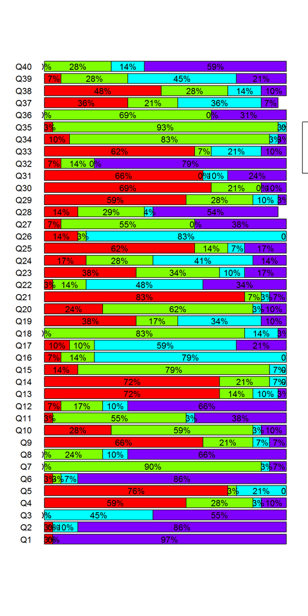

```r
text(x = midterm.tbl[1, ] / 2,
     y = b,
     labels = label.ptbl[1, ])
text(x = midterm.tbl[1, ] + midterm.tbl[2, ] / 2 ,
     y = b,
     labels = label.ptbl[2, ])
text(x = midterm.tbl[1, ] + midterm.tbl[2, ] + midterm.tbl[3, ] / 2,
     y = b,
     labels = label.ptbl[3, ])
text(x = midterm.tbl[1, ] + midterm.tbl[2, ] + midterm.tbl[3, ] + midterm.tbl[4, ]/ 2,
     y = b,
     labels = label.ptbl[4, ])
```

#### 점수

- 정답 맞춰보기
  - 정답 읽어들이기. `what = ""`로 설정하여 `char`취급.

```r
(ans <- scan("../data/ans.txt", what = ""))
```

```
##  [1] "라" "라" "라" "가" "가" "라" "나" "라" "가" "나" "나" "라" "가" "가" "나" "다" "다" "나" "가" "나" "가" "다" "가" "다" "가" "다" "나" "나" "가" "가" "가" "라" "가" "나" "나"
## [36] "나" "가" "나" "다" "나"
```

- 각 학생들의 답안과 맞춰보기 위하여 정답표 작성.
  - 문항별로 정답과 비교하기 위하여 각 문항을 리스트의 원소로 분리
  - `split()` 의 기능과 한계에 유의. `factor` 성격으로부터 `1, 10, 11, ..., 2, 20, ..., 3, 4, 5, ... , 9`로 순서를 잡게 되므로 다시 한번 정리할 필요.

```r
(ans.l <- split(ans,
                f = paste("A", 1:40, sep = "")))
```

```
## $A1
## [1] "라"
##
## $A10
## [1] "나"
##
## $A11
## [1] "나"
##
## $A12
## [1] "라"
##
## $A13
## [1] "가"
##
## $A14
## [1] "가"
##
## $A15
## [1] "나"
##
## $A16
## [1] "다"
##
## $A17
## [1] "다"
##
## $A18
## [1] "나"
##
## $A19
## [1] "가"
##
## $A2
## [1] "라"
##
## $A20
## [1] "나"
##
## $A21
```

[output cut: 64 more lines]

```
##
## $A5
## [1] "가"
##
## $A6
## [1] "라"
##
## $A7
## [1] "나"
##
## $A8
## [1] "라"
##
## $A9
## [1] "가"
```

```r
(ans.l.2 <- ans.l[paste("A", 1:40, sep = "")])
```

```
## $A1
## [1] "라"
##
## $A2
## [1] "라"
##
## $A3
## [1] "라"
##
## $A4
## [1] "가"
##
## $A5
## [1] "가"
##
## $A6
## [1] "라"
##
## $A7
## [1] "나"
##
## $A8
## [1] "라"
##
## $A9
## [1] "가"
##
## $A10
## [1] "나"
##
## $A11
## [1] "나"
##
## $A12
## [1] "라"
##
## $A13
## [1] "가"
##
## $A14
```

[output cut: 64 more lines]

```
##
## $A36
## [1] "나"
##
## $A37
## [1] "가"
##
## $A38
## [1] "나"
##
## $A39
## [1] "다"
##
## $A40
## [1] "나"
```

##### 정답과 대조하여 R(Right)/W(Wrong) 표시

- 채점표라는 의미의 `midterm.marks` 로 저장, (# 표시한 방식으로는 작동하지 않음)

```r
# midterm.marks.rw.q1_3 <- mapply(function(x, y) factor(ifelse(x == y, "R", "W")), y = ans.l.2[1:3], midterm[, 1:3])
midterm.marks.rw <- mapply(function(x, y) factor(ifelse(x == y, "R", "W")), y = ans.l.2, midterm)
# midterm.marks.rw <- mapply(function(x, y = ans.l.2) factor(ifelse(x == y, "R", "W")), midterm[, -26])
# midterm.marks.rw <- sapply(midterm, function(x, y = ans.l.2) factor(ifelse(x == y, "R", "W")))
kable(midterm.marks.rw[, 1:20])
```

| A1 | A2 | A3 | A4 | A5 | A6 | A7 | A8 | A9 | A10 | A11 | A12 | A13 | A14 | A15 | A16 | A17 | A18 | A19 | A20 |
| --- | --- | --- | --- | --- | --- | --- | --- | --- | --- | --- | --- | --- | --- | --- | --- | --- | --- | --- | --- |
| R | R | R | W | R | R | R | R | R | R | R | R | R | W | W | W | W | R | W | R |
| R | R | W | R | R | R | R | R | R | W | R | W | R | R | R | R | R | R | R | R |
| R | R | R | R | R | R | R | R | R | R | W | R | R | R | R | R | R | R | R | W |
| R | R | R | R | R | R | R | R | R | R | R | R | R | W | R | W | R | R | W | R |
| R | R | W | R | R | R | R | R | W | R | R | R | R | R | R | R | W | R | R | R |
| R | R | R | R | R | R | R | R | R | R | R | W | R | R | R | R | W | R | W | R |
| R | R | W | W | W | R | R | W | W | W | W | R | W | W | R | R | W | R | W | W |
| R | R | R | R | R | R | R | R | R | R | W | R | R | R | R | R | R | R | R | R |
| R | W | R | W | R | W | R | W | R | W | W | W | W | W | W | R | R | W | W | W |
| R | R | R | W | R | W | W | W | W | W | R | W | R | W | W | W | W | W | W | R |
| R | R | R | W | R | R | R | R | R | R | R | R | R | R | R | R | R | R | R | R |
| R | W | R | R | W | R | R | W | W | W | W | W | W | R | W | W | W | W | W | R |
| R | R | W | R | R | R | R | R | R | R | W | R | R | R | R | R | R | R | W | W |
| R | W | W | W | W | R | W | W | R | W | R | R | R | R | R | R | R | R | R | R |
| R | R | W | R | W | R | R | W | W | W | R | R | W | W | R | R | W | R | W | W |
| R | R | R | W | R | R | R | W | W | W | R | W | W | W | R | R | R | R | R | W |
| R | R | R | R | R | R | R | R | R | R | W | R | R | R | R | R | R | R | R | R |
| R | W | R | R | R | R | R | R | R | R | W | R | W | R | R | R | W | R | W | R |
| R | R | R | R | R | R | R | R | R | R | W | R | R | R | W | R | W | R | R | R |
| R | R | W | W | R | R | R | R | R | R | W | W | R | W | R | W | R | R | W | W |
| R | R | W | R | R | R | R | R | R | R | R | R | R | R | R | R | R | R | R | W |
| R | R | R | R | R | R | W | R | W | R | R | R | W | R | R | R | W | R | W | W |
| R | R | R | R | W | R | R | R | W | W | W | W | R | R | R | R | R | R | W | W |
| R | R | W | R | R | R | R | R | R | R | R | R | R | R | R | R | R | R | R | R |
| NA | NA | NA | NA | NA | NA | NA | NA | NA | NA | NA | NA | NA | NA | NA | NA | NA | NA | NA | NA |
| R | R | W | W | R | R | R | R | R | W | R | R | R | R | R | R | W | R | W | R |
| W | R | R | W | W | W | R | W | W | W | W | W | W | R | W | W | R | W | W | W |
| R | R | W | W | W | W | R | W | W | W | W | R | R | R | R | R | W | W | W | R |
| R | R | W | R | R | R | R | R | R | R | R | R | R | R | R | R | R | R | W | R |
| R | R | W | W | R | R | R | W | R | R | R | W | R | R | R | R | R | R | W | R |

```r
kable(midterm.marks.rw[, 21:40])
```

| A21 | A22 | A23 | A24 | A25 | A26 | A27 | A28 | A29 | A30 | A31 | A32 | A33 | A34 | A35 | A36 | A37 | A38 | A39 | A40 |
| --- | --- | --- | --- | --- | --- | --- | --- | --- | --- | --- | --- | --- | --- | --- | --- | --- | --- | --- | --- |
| R | R | R | W | W | R | W | R | R | W | R | R | R | R | R | W | W | W | R | R |
| R | R | W | R | W | R | W | NA | W | W | R | R | W | R | R | R | W | W | R | W |
| R | R | W | R | R | R | R | R | R | R | W | R | W | R | R | W | W | W | W | W |
| R | R | W | W | R | W | W | R | R | R | R | R | R | R | R | W | W | W | R | W |
| R | W | R | W | R | R | R | W | W | R | R | R | R | R | R | R | R | R | R | R |
| R | W | W | R | R | R | R | R | R | R | W | R | R | R | R | R | W | W | R | W |
| R | W | W | W | W | W | W | W | W | W | W | W | W | R | R | R | W | W | W | W |
| R | R | R | R | R | R | R | R | R | R | R | R | R | R | R | R | R | R | R | R |
| R | W | W | W | W | R | R | W | W | R | W | W | W | W | R | R | W | W | W | R |
| W | W | R | W | R | R | W | W | W | W | R | W | R | W | W | R | R | R | R | R |
| R | W | W | R | R | R | R | W | R | R | R | R | R | R | R | R | R | R | R | W |
| R | R | W | W | R | W | W | W | R | W | W | W | R | W | R | W | W | W | W | W |
| R | W | W | W | R | R | R | W | W | R | R | R | R | R | R | R | R | W | R | W |
| R | W | R | W | W | W | W | R | W | W | R | R | W | R | R | W | NA | W | R | W |
| R | W | W | R | W | R | W | W | R | R | W | R | R | R | R | R | R | W | W | W |
| W | R | W | W | W | R | W | W | W | R | R | W | W | R | W | R | W | R | W | W |
| R | R | R | W | R | R | R | R | R | R | R | R | R | R | R | R | W | R | R | R |
| R | R | R | R | W | R | R | W | R | W | W | R | R | R | R | W | W | W | R | W |
| R | R | R | R | R | R | W | W | R | R | R | R | W | R | R | R | W | W | W | W |
| R | W | W | W | R | R | R | R | W | W | W | R | W | R | R | R | W | R | W | W |
| W | W | W | R | R | R | R | W | W | R | R | R | R | R | R | R | W | W | W | W |
| R | W | R | R | W | R | R | W | R | R | R | R | R | R | R | R | R | W | W | W |
| R | W | R | W | R | R | R | W | W | R | R | R | R | W | R | R | W | R | W | R |
| R | W | W | W | R | R | R | W | R | R | R | R | R | R | R | R | R | W | W | W |
| NA | NA | NA | NA | NA | NA | NA | NA | NA | NA | NA | NA | NA | NA | NA | NA | NA | NA | NA | NA |
| W | R | R | W | R | R | W | W | R | R | R | R | R | R | R | R | R | W | W | W |
| W | W | W | W | W | R | W | W | W | R | W | R | W | W | R | W | W | W | W | W |
| R | R | W | R | W | R | W | W | R | W | W | W | W | R | R | W | R | W | W | R |
| R | R | W | R | R | R | R | W | R | R | R | R | R | R | R | R | W | W | R | W |
| R | R | W | W | R | W | R | W | R | R | R | R | W | R | R | W | W | W | W | W |

##### 학생별 점수 산출

```r
midterm.marks <- ifelse(midterm.marks.rw == "R", 1, 0)
kable(midterm.marks[, 1:20])
```

| A1 | A2 | A3 | A4 | A5 | A6 | A7 | A8 | A9 | A10 | A11 | A12 | A13 | A14 | A15 | A16 | A17 | A18 | A19 | A20 |
| --- | --- | --- | --- | --- | --- | --- | --- | --- | --- | --- | --- | --- | --- | --- | --- | --- | --- | --- | --- |
| 1 | 1 | 1 | 0 | 1 | 1 | 1 | 1 | 1 | 1 | 1 | 1 | 1 | 0 | 0 | 0 | 0 | 1 | 0 | 1 |
| 1 | 1 | 0 | 1 | 1 | 1 | 1 | 1 | 1 | 0 | 1 | 0 | 1 | 1 | 1 | 1 | 1 | 1 | 1 | 1 |
| 1 | 1 | 1 | 1 | 1 | 1 | 1 | 1 | 1 | 1 | 0 | 1 | 1 | 1 | 1 | 1 | 1 | 1 | 1 | 0 |
| 1 | 1 | 1 | 1 | 1 | 1 | 1 | 1 | 1 | 1 | 1 | 1 | 1 | 0 | 1 | 0 | 1 | 1 | 0 | 1 |
| 1 | 1 | 0 | 1 | 1 | 1 | 1 | 1 | 0 | 1 | 1 | 1 | 1 | 1 | 1 | 1 | 0 | 1 | 1 | 1 |
| 1 | 1 | 1 | 1 | 1 | 1 | 1 | 1 | 1 | 1 | 1 | 0 | 1 | 1 | 1 | 1 | 0 | 1 | 0 | 1 |
| 1 | 1 | 0 | 0 | 0 | 1 | 1 | 0 | 0 | 0 | 0 | 1 | 0 | 0 | 1 | 1 | 0 | 1 | 0 | 0 |
| 1 | 1 | 1 | 1 | 1 | 1 | 1 | 1 | 1 | 1 | 0 | 1 | 1 | 1 | 1 | 1 | 1 | 1 | 1 | 1 |
| 1 | 0 | 1 | 0 | 1 | 0 | 1 | 0 | 1 | 0 | 0 | 0 | 0 | 0 | 0 | 1 | 1 | 0 | 0 | 0 |
| 1 | 1 | 1 | 0 | 1 | 0 | 0 | 0 | 0 | 0 | 1 | 0 | 1 | 0 | 0 | 0 | 0 | 0 | 0 | 1 |
| 1 | 1 | 1 | 0 | 1 | 1 | 1 | 1 | 1 | 1 | 1 | 1 | 1 | 1 | 1 | 1 | 1 | 1 | 1 | 1 |
| 1 | 0 | 1 | 1 | 0 | 1 | 1 | 0 | 0 | 0 | 0 | 0 | 0 | 1 | 0 | 0 | 0 | 0 | 0 | 1 |
| 1 | 1 | 0 | 1 | 1 | 1 | 1 | 1 | 1 | 1 | 0 | 1 | 1 | 1 | 1 | 1 | 1 | 1 | 0 | 0 |
| 1 | 0 | 0 | 0 | 0 | 1 | 0 | 0 | 1 | 0 | 1 | 1 | 1 | 1 | 1 | 1 | 1 | 1 | 1 | 1 |
| 1 | 1 | 0 | 1 | 0 | 1 | 1 | 0 | 0 | 0 | 1 | 1 | 0 | 0 | 1 | 1 | 0 | 1 | 0 | 0 |
| 1 | 1 | 1 | 0 | 1 | 1 | 1 | 0 | 0 | 0 | 1 | 0 | 0 | 0 | 1 | 1 | 1 | 1 | 1 | 0 |
| 1 | 1 | 1 | 1 | 1 | 1 | 1 | 1 | 1 | 1 | 0 | 1 | 1 | 1 | 1 | 1 | 1 | 1 | 1 | 1 |
| 1 | 0 | 1 | 1 | 1 | 1 | 1 | 1 | 1 | 1 | 0 | 1 | 0 | 1 | 1 | 1 | 0 | 1 | 0 | 1 |
| 1 | 1 | 1 | 1 | 1 | 1 | 1 | 1 | 1 | 1 | 0 | 1 | 1 | 1 | 0 | 1 | 0 | 1 | 1 | 1 |
| 1 | 1 | 0 | 0 | 1 | 1 | 1 | 1 | 1 | 1 | 0 | 0 | 1 | 0 | 1 | 0 | 1 | 1 | 0 | 0 |
| 1 | 1 | 0 | 1 | 1 | 1 | 1 | 1 | 1 | 1 | 1 | 1 | 1 | 1 | 1 | 1 | 1 | 1 | 1 | 0 |
| 1 | 1 | 1 | 1 | 1 | 1 | 0 | 1 | 0 | 1 | 1 | 1 | 0 | 1 | 1 | 1 | 0 | 1 | 0 | 0 |
| 1 | 1 | 1 | 1 | 0 | 1 | 1 | 1 | 0 | 0 | 0 | 0 | 1 | 1 | 1 | 1 | 1 | 1 | 0 | 0 |
| 1 | 1 | 0 | 1 | 1 | 1 | 1 | 1 | 1 | 1 | 1 | 1 | 1 | 1 | 1 | 1 | 1 | 1 | 1 | 1 |
| NA | NA | NA | NA | NA | NA | NA | NA | NA | NA | NA | NA | NA | NA | NA | NA | NA | NA | NA | NA |
| 1 | 1 | 0 | 0 | 1 | 1 | 1 | 1 | 1 | 0 | 1 | 1 | 1 | 1 | 1 | 1 | 0 | 1 | 0 | 1 |
| 0 | 1 | 1 | 0 | 0 | 0 | 1 | 0 | 0 | 0 | 0 | 0 | 0 | 1 | 0 | 0 | 1 | 0 | 0 | 0 |
| 1 | 1 | 0 | 0 | 0 | 0 | 1 | 0 | 0 | 0 | 0 | 1 | 1 | 1 | 1 | 1 | 0 | 0 | 0 | 1 |
| 1 | 1 | 0 | 1 | 1 | 1 | 1 | 1 | 1 | 1 | 1 | 1 | 1 | 1 | 1 | 1 | 1 | 1 | 0 | 1 |
| 1 | 1 | 0 | 0 | 1 | 1 | 1 | 0 | 1 | 1 | 1 | 0 | 1 | 1 | 1 | 1 | 1 | 1 | 0 | 1 |

```r
kable(midterm.marks[, 21:40])
```

| A21 | A22 | A23 | A24 | A25 | A26 | A27 | A28 | A29 | A30 | A31 | A32 | A33 | A34 | A35 | A36 | A37 | A38 | A39 | A40 |
| --- | --- | --- | --- | --- | --- | --- | --- | --- | --- | --- | --- | --- | --- | --- | --- | --- | --- | --- | --- |
| 1 | 1 | 1 | 0 | 0 | 1 | 0 | 1 | 1 | 0 | 1 | 1 | 1 | 1 | 1 | 0 | 0 | 0 | 1 | 1 |
| 1 | 1 | 0 | 1 | 0 | 1 | 0 | NA | 0 | 0 | 1 | 1 | 0 | 1 | 1 | 1 | 0 | 0 | 1 | 0 |
| 1 | 1 | 0 | 1 | 1 | 1 | 1 | 1 | 1 | 1 | 0 | 1 | 0 | 1 | 1 | 0 | 0 | 0 | 0 | 0 |
| 1 | 1 | 0 | 0 | 1 | 0 | 0 | 1 | 1 | 1 | 1 | 1 | 1 | 1 | 1 | 0 | 0 | 0 | 1 | 0 |
| 1 | 0 | 1 | 0 | 1 | 1 | 1 | 0 | 0 | 1 | 1 | 1 | 1 | 1 | 1 | 1 | 1 | 1 | 1 | 1 |
| 1 | 0 | 0 | 1 | 1 | 1 | 1 | 1 | 1 | 1 | 0 | 1 | 1 | 1 | 1 | 1 | 0 | 0 | 1 | 0 |
| 1 | 0 | 0 | 0 | 0 | 0 | 0 | 0 | 0 | 0 | 0 | 0 | 0 | 1 | 1 | 1 | 0 | 0 | 0 | 0 |
| 1 | 1 | 1 | 1 | 1 | 1 | 1 | 1 | 1 | 1 | 1 | 1 | 1 | 1 | 1 | 1 | 1 | 1 | 1 | 1 |
| 1 | 0 | 0 | 0 | 0 | 1 | 1 | 0 | 0 | 1 | 0 | 0 | 0 | 0 | 1 | 1 | 0 | 0 | 0 | 1 |
| 0 | 0 | 1 | 0 | 1 | 1 | 0 | 0 | 0 | 0 | 1 | 0 | 1 | 0 | 0 | 1 | 1 | 1 | 1 | 1 |
| 1 | 0 | 0 | 1 | 1 | 1 | 1 | 0 | 1 | 1 | 1 | 1 | 1 | 1 | 1 | 1 | 1 | 1 | 1 | 0 |
| 1 | 1 | 0 | 0 | 1 | 0 | 0 | 0 | 1 | 0 | 0 | 0 | 1 | 0 | 1 | 0 | 0 | 0 | 0 | 0 |
| 1 | 0 | 0 | 0 | 1 | 1 | 1 | 0 | 0 | 1 | 1 | 1 | 1 | 1 | 1 | 1 | 1 | 0 | 1 | 0 |
| 1 | 0 | 1 | 0 | 0 | 0 | 0 | 1 | 0 | 0 | 1 | 1 | 0 | 1 | 1 | 0 | NA | 0 | 1 | 0 |
| 1 | 0 | 0 | 1 | 0 | 1 | 0 | 0 | 1 | 1 | 0 | 1 | 1 | 1 | 1 | 1 | 1 | 0 | 0 | 0 |
| 0 | 1 | 0 | 0 | 0 | 1 | 0 | 0 | 0 | 1 | 1 | 0 | 0 | 1 | 0 | 1 | 0 | 1 | 0 | 0 |
| 1 | 1 | 1 | 0 | 1 | 1 | 1 | 1 | 1 | 1 | 1 | 1 | 1 | 1 | 1 | 1 | 0 | 1 | 1 | 1 |
| 1 | 1 | 1 | 1 | 0 | 1 | 1 | 0 | 1 | 0 | 0 | 1 | 1 | 1 | 1 | 0 | 0 | 0 | 1 | 0 |
| 1 | 1 | 1 | 1 | 1 | 1 | 0 | 0 | 1 | 1 | 1 | 1 | 0 | 1 | 1 | 1 | 0 | 0 | 0 | 0 |
| 1 | 0 | 0 | 0 | 1 | 1 | 1 | 1 | 0 | 0 | 0 | 1 | 0 | 1 | 1 | 1 | 0 | 1 | 0 | 0 |
| 0 | 0 | 0 | 1 | 1 | 1 | 1 | 0 | 0 | 1 | 1 | 1 | 1 | 1 | 1 | 1 | 0 | 0 | 0 | 0 |
| 1 | 0 | 1 | 1 | 0 | 1 | 1 | 0 | 1 | 1 | 1 | 1 | 1 | 1 | 1 | 1 | 1 | 0 | 0 | 0 |
| 1 | 0 | 1 | 0 | 1 | 1 | 1 | 0 | 0 | 1 | 1 | 1 | 1 | 0 | 1 | 1 | 0 | 1 | 0 | 1 |
| 1 | 0 | 0 | 0 | 1 | 1 | 1 | 0 | 1 | 1 | 1 | 1 | 1 | 1 | 1 | 1 | 1 | 0 | 0 | 0 |
| NA | NA | NA | NA | NA | NA | NA | NA | NA | NA | NA | NA | NA | NA | NA | NA | NA | NA | NA | NA |
| 0 | 1 | 1 | 0 | 1 | 1 | 0 | 0 | 1 | 1 | 1 | 1 | 1 | 1 | 1 | 1 | 1 | 0 | 0 | 0 |
| 0 | 0 | 0 | 0 | 0 | 1 | 0 | 0 | 0 | 1 | 0 | 1 | 0 | 0 | 1 | 0 | 0 | 0 | 0 | 0 |
| 1 | 1 | 0 | 1 | 0 | 1 | 0 | 0 | 1 | 0 | 0 | 0 | 0 | 1 | 1 | 0 | 1 | 0 | 0 | 1 |
| 1 | 1 | 0 | 1 | 1 | 1 | 1 | 0 | 1 | 1 | 1 | 1 | 1 | 1 | 1 | 1 | 0 | 0 | 1 | 0 |
| 1 | 1 | 0 | 0 | 1 | 0 | 1 | 0 | 1 | 1 | 1 | 1 | 0 | 1 | 1 | 0 | 0 | 0 | 0 | 0 |

```r
midterm.score <- midterm.marks * 2.5
kable(data.frame("순번" = 1:nrow(midterm), midterm.score)[1:20])
```

| 순번 | A1 | A2 | A3 | A4 | A5 | A6 | A7 | A8 | A9 | A10 | A11 | A12 | A13 | A14 | A15 | A16 | A17 | A18 | A19 |
| --- | --- | --- | --- | --- | --- | --- | --- | --- | --- | --- | --- | --- | --- | --- | --- | --- | --- | --- | --- |
| 1 | 2.5 | 2.5 | 2.5 | 0.0 | 2.5 | 2.5 | 2.5 | 2.5 | 2.5 | 2.5 | 2.5 | 2.5 | 2.5 | 0.0 | 0.0 | 0.0 | 0.0 | 2.5 | 0.0 |
| 2 | 2.5 | 2.5 | 0.0 | 2.5 | 2.5 | 2.5 | 2.5 | 2.5 | 2.5 | 0.0 | 2.5 | 0.0 | 2.5 | 2.5 | 2.5 | 2.5 | 2.5 | 2.5 | 2.5 |
| 3 | 2.5 | 2.5 | 2.5 | 2.5 | 2.5 | 2.5 | 2.5 | 2.5 | 2.5 | 2.5 | 0.0 | 2.5 | 2.5 | 2.5 | 2.5 | 2.5 | 2.5 | 2.5 | 2.5 |
| 4 | 2.5 | 2.5 | 2.5 | 2.5 | 2.5 | 2.5 | 2.5 | 2.5 | 2.5 | 2.5 | 2.5 | 2.5 | 2.5 | 0.0 | 2.5 | 0.0 | 2.5 | 2.5 | 0.0 |
| 5 | 2.5 | 2.5 | 0.0 | 2.5 | 2.5 | 2.5 | 2.5 | 2.5 | 0.0 | 2.5 | 2.5 | 2.5 | 2.5 | 2.5 | 2.5 | 2.5 | 0.0 | 2.5 | 2.5 |
| 6 | 2.5 | 2.5 | 2.5 | 2.5 | 2.5 | 2.5 | 2.5 | 2.5 | 2.5 | 2.5 | 2.5 | 0.0 | 2.5 | 2.5 | 2.5 | 2.5 | 0.0 | 2.5 | 0.0 |
| 7 | 2.5 | 2.5 | 0.0 | 0.0 | 0.0 | 2.5 | 2.5 | 0.0 | 0.0 | 0.0 | 0.0 | 2.5 | 0.0 | 0.0 | 2.5 | 2.5 | 0.0 | 2.5 | 0.0 |
| 8 | 2.5 | 2.5 | 2.5 | 2.5 | 2.5 | 2.5 | 2.5 | 2.5 | 2.5 | 2.5 | 0.0 | 2.5 | 2.5 | 2.5 | 2.5 | 2.5 | 2.5 | 2.5 | 2.5 |
| 9 | 2.5 | 0.0 | 2.5 | 0.0 | 2.5 | 0.0 | 2.5 | 0.0 | 2.5 | 0.0 | 0.0 | 0.0 | 0.0 | 0.0 | 0.0 | 2.5 | 2.5 | 0.0 | 0.0 |
| 10 | 2.5 | 2.5 | 2.5 | 0.0 | 2.5 | 0.0 | 0.0 | 0.0 | 0.0 | 0.0 | 2.5 | 0.0 | 2.5 | 0.0 | 0.0 | 0.0 | 0.0 | 0.0 | 0.0 |
| 11 | 2.5 | 2.5 | 2.5 | 0.0 | 2.5 | 2.5 | 2.5 | 2.5 | 2.5 | 2.5 | 2.5 | 2.5 | 2.5 | 2.5 | 2.5 | 2.5 | 2.5 | 2.5 | 2.5 |
| 12 | 2.5 | 0.0 | 2.5 | 2.5 | 0.0 | 2.5 | 2.5 | 0.0 | 0.0 | 0.0 | 0.0 | 0.0 | 0.0 | 2.5 | 0.0 | 0.0 | 0.0 | 0.0 | 0.0 |
| 13 | 2.5 | 2.5 | 0.0 | 2.5 | 2.5 | 2.5 | 2.5 | 2.5 | 2.5 | 2.5 | 0.0 | 2.5 | 2.5 | 2.5 | 2.5 | 2.5 | 2.5 | 2.5 | 0.0 |
| 14 | 2.5 | 0.0 | 0.0 | 0.0 | 0.0 | 2.5 | 0.0 | 0.0 | 2.5 | 0.0 | 2.5 | 2.5 | 2.5 | 2.5 | 2.5 | 2.5 | 2.5 | 2.5 | 2.5 |
| 15 | 2.5 | 2.5 | 0.0 | 2.5 | 0.0 | 2.5 | 2.5 | 0.0 | 0.0 | 0.0 | 2.5 | 2.5 | 0.0 | 0.0 | 2.5 | 2.5 | 0.0 | 2.5 | 0.0 |
| 16 | 2.5 | 2.5 | 2.5 | 0.0 | 2.5 | 2.5 | 2.5 | 0.0 | 0.0 | 0.0 | 2.5 | 0.0 | 0.0 | 0.0 | 2.5 | 2.5 | 2.5 | 2.5 | 2.5 |
| 17 | 2.5 | 2.5 | 2.5 | 2.5 | 2.5 | 2.5 | 2.5 | 2.5 | 2.5 | 2.5 | 0.0 | 2.5 | 2.5 | 2.5 | 2.5 | 2.5 | 2.5 | 2.5 | 2.5 |
| 18 | 2.5 | 0.0 | 2.5 | 2.5 | 2.5 | 2.5 | 2.5 | 2.5 | 2.5 | 2.5 | 0.0 | 2.5 | 0.0 | 2.5 | 2.5 | 2.5 | 0.0 | 2.5 | 0.0 |
| 19 | 2.5 | 2.5 | 2.5 | 2.5 | 2.5 | 2.5 | 2.5 | 2.5 | 2.5 | 2.5 | 0.0 | 2.5 | 2.5 | 2.5 | 0.0 | 2.5 | 0.0 | 2.5 | 2.5 |
| 20 | 2.5 | 2.5 | 0.0 | 0.0 | 2.5 | 2.5 | 2.5 | 2.5 | 2.5 | 2.5 | 0.0 | 0.0 | 2.5 | 0.0 | 2.5 | 0.0 | 2.5 | 2.5 | 0.0 |
| 21 | 2.5 | 2.5 | 0.0 | 2.5 | 2.5 | 2.5 | 2.5 | 2.5 | 2.5 | 2.5 | 2.5 | 2.5 | 2.5 | 2.5 | 2.5 | 2.5 | 2.5 | 2.5 | 2.5 |
| 22 | 2.5 | 2.5 | 2.5 | 2.5 | 2.5 | 2.5 | 0.0 | 2.5 | 0.0 | 2.5 | 2.5 | 2.5 | 0.0 | 2.5 | 2.5 | 2.5 | 0.0 | 2.5 | 0.0 |
| 23 | 2.5 | 2.5 | 2.5 | 2.5 | 0.0 | 2.5 | 2.5 | 2.5 | 0.0 | 0.0 | 0.0 | 0.0 | 2.5 | 2.5 | 2.5 | 2.5 | 2.5 | 2.5 | 0.0 |
| 24 | 2.5 | 2.5 | 0.0 | 2.5 | 2.5 | 2.5 | 2.5 | 2.5 | 2.5 | 2.5 | 2.5 | 2.5 | 2.5 | 2.5 | 2.5 | 2.5 | 2.5 | 2.5 | 2.5 |
| 25 | NA | NA | NA | NA | NA | NA | NA | NA | NA | NA | NA | NA | NA | NA | NA | NA | NA | NA | NA |
| 26 | 2.5 | 2.5 | 0.0 | 0.0 | 2.5 | 2.5 | 2.5 | 2.5 | 2.5 | 0.0 | 2.5 | 2.5 | 2.5 | 2.5 | 2.5 | 2.5 | 0.0 | 2.5 | 0.0 |
| 27 | 0.0 | 2.5 | 2.5 | 0.0 | 0.0 | 0.0 | 2.5 | 0.0 | 0.0 | 0.0 | 0.0 | 0.0 | 0.0 | 2.5 | 0.0 | 0.0 | 2.5 | 0.0 | 0.0 |
| 28 | 2.5 | 2.5 | 0.0 | 0.0 | 0.0 | 0.0 | 2.5 | 0.0 | 0.0 | 0.0 | 0.0 | 2.5 | 2.5 | 2.5 | 2.5 | 2.5 | 0.0 | 0.0 | 0.0 |
| 29 | 2.5 | 2.5 | 0.0 | 2.5 | 2.5 | 2.5 | 2.5 | 2.5 | 2.5 | 2.5 | 2.5 | 2.5 | 2.5 | 2.5 | 2.5 | 2.5 | 2.5 | 2.5 | 0.0 |
| 30 | 2.5 | 2.5 | 0.0 | 0.0 | 2.5 | 2.5 | 2.5 | 0.0 | 2.5 | 2.5 | 2.5 | 0.0 | 2.5 | 2.5 | 2.5 | 2.5 | 2.5 | 2.5 | 0.0 |

```r
# kable(data.frame("학번" = midterm.roll$id, midterm.score)[1:20])
kable(data.frame("순번" = 1:nrow(midterm), midterm.score)[21:40])
```

| A20 | A21 | A22 | A23 | A24 | A25 | A26 | A27 | A28 | A29 | A30 | A31 | A32 | A33 | A34 | A35 | A36 | A37 | A38 | A39 |
| --- | --- | --- | --- | --- | --- | --- | --- | --- | --- | --- | --- | --- | --- | --- | --- | --- | --- | --- | --- |
| 2.5 | 2.5 | 2.5 | 2.5 | 0.0 | 0.0 | 2.5 | 0.0 | 2.5 | 2.5 | 0.0 | 2.5 | 2.5 | 2.5 | 2.5 | 2.5 | 0.0 | 0.0 | 0.0 | 2.5 |
| 2.5 | 2.5 | 2.5 | 0.0 | 2.5 | 0.0 | 2.5 | 0.0 | NA | 0.0 | 0.0 | 2.5 | 2.5 | 0.0 | 2.5 | 2.5 | 2.5 | 0.0 | 0.0 | 2.5 |
| 0.0 | 2.5 | 2.5 | 0.0 | 2.5 | 2.5 | 2.5 | 2.5 | 2.5 | 2.5 | 2.5 | 0.0 | 2.5 | 0.0 | 2.5 | 2.5 | 0.0 | 0.0 | 0.0 | 0.0 |
| 2.5 | 2.5 | 2.5 | 0.0 | 0.0 | 2.5 | 0.0 | 0.0 | 2.5 | 2.5 | 2.5 | 2.5 | 2.5 | 2.5 | 2.5 | 2.5 | 0.0 | 0.0 | 0.0 | 2.5 |
| 2.5 | 2.5 | 0.0 | 2.5 | 0.0 | 2.5 | 2.5 | 2.5 | 0.0 | 0.0 | 2.5 | 2.5 | 2.5 | 2.5 | 2.5 | 2.5 | 2.5 | 2.5 | 2.5 | 2.5 |
| 2.5 | 2.5 | 0.0 | 0.0 | 2.5 | 2.5 | 2.5 | 2.5 | 2.5 | 2.5 | 2.5 | 0.0 | 2.5 | 2.5 | 2.5 | 2.5 | 2.5 | 0.0 | 0.0 | 2.5 |
| 0.0 | 2.5 | 0.0 | 0.0 | 0.0 | 0.0 | 0.0 | 0.0 | 0.0 | 0.0 | 0.0 | 0.0 | 0.0 | 0.0 | 2.5 | 2.5 | 2.5 | 0.0 | 0.0 | 0.0 |
| 2.5 | 2.5 | 2.5 | 2.5 | 2.5 | 2.5 | 2.5 | 2.5 | 2.5 | 2.5 | 2.5 | 2.5 | 2.5 | 2.5 | 2.5 | 2.5 | 2.5 | 2.5 | 2.5 | 2.5 |
| 0.0 | 2.5 | 0.0 | 0.0 | 0.0 | 0.0 | 2.5 | 2.5 | 0.0 | 0.0 | 2.5 | 0.0 | 0.0 | 0.0 | 0.0 | 2.5 | 2.5 | 0.0 | 0.0 | 0.0 |
| 2.5 | 0.0 | 0.0 | 2.5 | 0.0 | 2.5 | 2.5 | 0.0 | 0.0 | 0.0 | 0.0 | 2.5 | 0.0 | 2.5 | 0.0 | 0.0 | 2.5 | 2.5 | 2.5 | 2.5 |
| 2.5 | 2.5 | 0.0 | 0.0 | 2.5 | 2.5 | 2.5 | 2.5 | 0.0 | 2.5 | 2.5 | 2.5 | 2.5 | 2.5 | 2.5 | 2.5 | 2.5 | 2.5 | 2.5 | 2.5 |
| 2.5 | 2.5 | 2.5 | 0.0 | 0.0 | 2.5 | 0.0 | 0.0 | 0.0 | 2.5 | 0.0 | 0.0 | 0.0 | 2.5 | 0.0 | 2.5 | 0.0 | 0.0 | 0.0 | 0.0 |
| 0.0 | 2.5 | 0.0 | 0.0 | 0.0 | 2.5 | 2.5 | 2.5 | 0.0 | 0.0 | 2.5 | 2.5 | 2.5 | 2.5 | 2.5 | 2.5 | 2.5 | 2.5 | 0.0 | 2.5 |
| 2.5 | 2.5 | 0.0 | 2.5 | 0.0 | 0.0 | 0.0 | 0.0 | 2.5 | 0.0 | 0.0 | 2.5 | 2.5 | 0.0 | 2.5 | 2.5 | 0.0 | NA | 0.0 | 2.5 |
| 0.0 | 2.5 | 0.0 | 0.0 | 2.5 | 0.0 | 2.5 | 0.0 | 0.0 | 2.5 | 2.5 | 0.0 | 2.5 | 2.5 | 2.5 | 2.5 | 2.5 | 2.5 | 0.0 | 0.0 |
| 0.0 | 0.0 | 2.5 | 0.0 | 0.0 | 0.0 | 2.5 | 0.0 | 0.0 | 0.0 | 2.5 | 2.5 | 0.0 | 0.0 | 2.5 | 0.0 | 2.5 | 0.0 | 2.5 | 0.0 |
| 2.5 | 2.5 | 2.5 | 2.5 | 0.0 | 2.5 | 2.5 | 2.5 | 2.5 | 2.5 | 2.5 | 2.5 | 2.5 | 2.5 | 2.5 | 2.5 | 2.5 | 0.0 | 2.5 | 2.5 |
| 2.5 | 2.5 | 2.5 | 2.5 | 2.5 | 0.0 | 2.5 | 2.5 | 0.0 | 2.5 | 0.0 | 0.0 | 2.5 | 2.5 | 2.5 | 2.5 | 0.0 | 0.0 | 0.0 | 2.5 |
| 2.5 | 2.5 | 2.5 | 2.5 | 2.5 | 2.5 | 2.5 | 0.0 | 0.0 | 2.5 | 2.5 | 2.5 | 2.5 | 0.0 | 2.5 | 2.5 | 2.5 | 0.0 | 0.0 | 0.0 |
| 0.0 | 2.5 | 0.0 | 0.0 | 0.0 | 2.5 | 2.5 | 2.5 | 2.5 | 0.0 | 0.0 | 0.0 | 2.5 | 0.0 | 2.5 | 2.5 | 2.5 | 0.0 | 2.5 | 0.0 |
| 0.0 | 0.0 | 0.0 | 0.0 | 2.5 | 2.5 | 2.5 | 2.5 | 0.0 | 0.0 | 2.5 | 2.5 | 2.5 | 2.5 | 2.5 | 2.5 | 2.5 | 0.0 | 0.0 | 0.0 |
| 0.0 | 2.5 | 0.0 | 2.5 | 2.5 | 0.0 | 2.5 | 2.5 | 0.0 | 2.5 | 2.5 | 2.5 | 2.5 | 2.5 | 2.5 | 2.5 | 2.5 | 2.5 | 0.0 | 0.0 |
| 0.0 | 2.5 | 0.0 | 2.5 | 0.0 | 2.5 | 2.5 | 2.5 | 0.0 | 0.0 | 2.5 | 2.5 | 2.5 | 2.5 | 0.0 | 2.5 | 2.5 | 0.0 | 2.5 | 0.0 |
| 2.5 | 2.5 | 0.0 | 0.0 | 0.0 | 2.5 | 2.5 | 2.5 | 0.0 | 2.5 | 2.5 | 2.5 | 2.5 | 2.5 | 2.5 | 2.5 | 2.5 | 2.5 | 0.0 | 0.0 |
| NA | NA | NA | NA | NA | NA | NA | NA | NA | NA | NA | NA | NA | NA | NA | NA | NA | NA | NA | NA |
| 2.5 | 0.0 | 2.5 | 2.5 | 0.0 | 2.5 | 2.5 | 0.0 | 0.0 | 2.5 | 2.5 | 2.5 | 2.5 | 2.5 | 2.5 | 2.5 | 2.5 | 2.5 | 0.0 | 0.0 |
| 0.0 | 0.0 | 0.0 | 0.0 | 0.0 | 0.0 | 2.5 | 0.0 | 0.0 | 0.0 | 2.5 | 0.0 | 2.5 | 0.0 | 0.0 | 2.5 | 0.0 | 0.0 | 0.0 | 0.0 |
| 2.5 | 2.5 | 2.5 | 0.0 | 2.5 | 0.0 | 2.5 | 0.0 | 0.0 | 2.5 | 0.0 | 0.0 | 0.0 | 0.0 | 2.5 | 2.5 | 0.0 | 2.5 | 0.0 | 0.0 |
| 2.5 | 2.5 | 2.5 | 0.0 | 2.5 | 2.5 | 2.5 | 2.5 | 0.0 | 2.5 | 2.5 | 2.5 | 2.5 | 2.5 | 2.5 | 2.5 | 2.5 | 0.0 | 0.0 | 2.5 |
| 2.5 | 2.5 | 2.5 | 0.0 | 0.0 | 2.5 | 0.0 | 2.5 | 0.0 | 2.5 | 2.5 | 2.5 | 2.5 | 0.0 | 2.5 | 2.5 | 0.0 | 0.0 | 0.0 | 0.0 |

```r
# kable(data.frame("학번" = midterm.roll$id, midterm.score)[21:40])
midterm.score <- apply(midterm.marks, 1, sum, na.rm = TRUE) * 2.5
midterm.score[midterm.score == 0] <- NA
which(midterm.score < 60)
```

```
##  [1]  7  9 10 12 14 15 16 20 27 28
```

```r
kable(data.frame("순번" = 1:nrow(midterm), "점수" = midterm.score))
```

| 순번 | 점수 |
| --- | --- |
| 1 | 67.5 |
| 2 | 67.5 |
| 3 | 75.0 |
| 4 | 72.5 |
| 5 | 82.5 |
| 6 | 77.5 |
| 7 | 30.0 |
| 8 | 97.5 |
| 9 | 35.0 |
| 10 | 42.5 |
| 11 | 87.5 |
| 12 | 32.5 |
| 13 | 72.5 |
| 14 | 52.5 |
| 15 | 52.5 |
| 16 | 47.5 |
| 17 | 92.5 |
| 18 | 67.5 |
| 19 | 75.0 |
| 20 | 55.0 |
| 21 | 72.5 |
| 22 | 70.0 |
| 23 | 65.0 |
| 24 | 80.0 |
| 25 | NA |
| 26 | 70.0 |
| 27 | 22.5 |
| 28 | 45.0 |
| 29 | 82.5 |
| 30 | 62.5 |

##### 문항별 정답률

- 결석한 경우와 일부 문항에 답을 내지 않은 경우를 구분하는 것이 핵심.
  - `midterm.marks`를 그대로 이용하면 쉽게 계산되나, `is.na`학습 목적으로 `midterm.mark.rw`에서 출발
  - 모든 문항에 NA로 답한 결석한 학생들의 인덱스를 먼저 찾아내고,

```r
apply(midterm.marks.rw, 1, function(x) all(is.na(x)))
```

```
##  [1] FALSE FALSE FALSE FALSE FALSE FALSE FALSE FALSE FALSE FALSE FALSE FALSE FALSE FALSE FALSE FALSE FALSE FALSE FALSE FALSE FALSE FALSE FALSE FALSE  TRUE FALSE FALSE FALSE FALSE
## [30] FALSE
```

```r
na.all <- which(apply(midterm.marks.rw, 1, function(x) all(is.na(x))))
```

- 정답률 계산
  - NA를 모두 오답처리한 후, 결석한 학생들만 다시 NA로 정정.
  - TRUE의 갯수를 합하여 평균.

```r
midterm.marks.2 <- midterm.marks.rw
midterm.marks.2[is.na(midterm.marks.2)] <- "W"
midterm.marks.2[na.all, ] <- NA
midterm.marks.2 <- ifelse(midterm.marks.2 == "R", 1, 0)
rate.by.item <- apply(midterm.marks.2, 2, mean, na.rm = TRUE) * 100
str(rate.by.item)
```

```
##  Named num [1:40] 96.6 86.2 55.2 58.6 75.9 ...
##  - attr(*, "names")= chr [1:40] "A1" "A2" "A3" "A4" ...
```

```r
rate.by.item <- as.matrix(rate.by.item, 40)
dimnames(rate.by.item) <- list("문항" =  paste("문", 1:40, sep = ""), "정답률" = "정답률")
colnames(rate.by.item) <- "정답률"
```

```r
kable(rate.by.item, digits = 3)
```

|  | 정답률 |
| --- | --- |
| 문1 | 96.552 |
| 문2 | 86.207 |
| 문3 | 55.172 |
| 문4 | 58.621 |
| 문5 | 75.862 |
| 문6 | 86.207 |
| 문7 | 89.655 |
| 문8 | 65.517 |
| 문9 | 65.517 |
| 문10 | 58.621 |
| 문11 | 55.172 |
| 문12 | 65.517 |
| 문13 | 72.414 |
| 문14 | 72.414 |
| 문15 | 79.310 |
| 문16 | 79.310 |
| 문17 | 58.621 |
| 문18 | 82.759 |
| 문19 | 37.931 |
| 문20 | 62.069 |
| 문21 | 82.759 |
| 문22 | 48.276 |
| 문23 | 37.931 |
| 문24 | 41.379 |
| 문25 | 62.069 |
| 문26 | 82.759 |
| 문27 | 55.172 |
| 문28 | 27.586 |
| 문29 | 58.621 |
| 문30 | 68.966 |
| 문31 | 65.517 |
| 문32 | 79.310 |
| 문33 | 62.069 |
| 문34 | 82.759 |
| 문35 | 93.103 |
| 문36 | 68.966 |
| 문37 | 34.483 |
| 문38 | 27.586 |
| 문39 | 44.828 |
| 문40 | 27.586 |

#### 어려운 문제?

##### 정답률 60% 이하

```r
kable(t(rate.by.item[which(rate.by.item <= 60), , drop = FALSE]))
```

|  | 문3 | 문4 | 문10 | 문11 | 문17 | 문19 | 문22 | 문23 | 문24 | 문27 | 문28 | 문29 | 문37 | 문38 | 문39 | 문40 |
| --- | --- | --- | --- | --- | --- | --- | --- | --- | --- | --- | --- | --- | --- | --- | --- | --- |
| 정답률 | 55.17241 | 58.62069 | 58.62069 | 55.17241 | 58.62069 | 37.93103 | 48.27586 | 37.93103 | 41.37931 | 55.17241 | 27.58621 | 58.62069 | 34.48276 | 27.58621 | 44.82759 | 27.58621 |

##### 정답률 50% 이하

```r
kable(t(rate.by.item[which(rate.by.item <= 50), , drop = FALSE]))
```

|  | 문19 | 문22 | 문23 | 문24 | 문28 | 문37 | 문38 | 문39 | 문40 |
| --- | --- | --- | --- | --- | --- | --- | --- | --- | --- |
| 정답률 | 37.93103 | 48.27586 | 37.93103 | 41.37931 | 27.58621 | 34.48276 | 27.58621 | 44.82759 | 27.58621 |

##### 정답률 40% 이하

```r
kable(t(rate.by.item[which(rate.by.item <= 40), , drop = FALSE]))
```

|  | 문19 | 문23 | 문28 | 문37 | 문38 | 문40 |
| --- | --- | --- | --- | --- | --- | --- |
| 정답률 | 37.93103 | 37.93103 | 27.58621 | 34.48276 | 27.58621 | 27.58621 |

##### 정답률 30% 이하

```r
kable(t(rate.by.item[which(rate.by.item <= 30), , drop = FALSE]))
```

|  | 문28 | 문38 | 문40 |
| --- | --- | --- | --- |
| 정답률 | 27.58621 | 27.58621 | 27.58621 |